# What Factors Make a Masterpiece?

Noah Love

8/16/2021

## Introduction

Throughout our semester in Masterpieces of Western Music, we studied a variety of pieces and composers, and yet haven’t arrived at a definitive set of characteristics that compose an individual masterpiece. Further, we compiled our own personal favorite songs, a playlist fit for if Manhattan was set adrift into the ocean and Columbia students alone chose the music we must survive on.

### Spotify Data Analysis

Spotify music provides an incredible API that has a wealth of information related to each and every song in their repository. Spotify themselves do the hard work of data processing individual characteristics like time signature and qualitative descriptors like loudness, instrumentalness or acousticness. There are broadly speaking 3 categories of factors:

- Mood: Danceability, Valence, Energy, Tempo
- Properties: Loudness, Speechiness, Instrumentalness
- Context: Liveness, Acousticness

Valence is a particularly fun and relavent feature for our class. Valence is musical positiveness conveyed by a track. Tracks with high valence sound more positive (happy, cheerful, euphoric), while tracks with low valence sound more negative (sad, depressed, angry). In a sense, Spotify is trying to deduce the affect of the song mathematically and giving that affect a number and continuum to exist on.

However, these characteristics aren’t always as black and white as they mean seem. Having a number between 0 and 1 for each characteristic seems definitive, and yet they are not obvious. One inherent problem with larger works is the difficulty have having one number, an average, describe an entire movement.

For example, we can look at Hector Berlioz’s Symphonie Fantastique

| track_name | valence | danceability | loudness | liveness | energy | tempo |
| --- | --- | --- | --- | --- | --- | --- |
| Symphonie fantastique, Op. 14, H. 48: I. Rêveries - Passions | 0.0409 | 0.178 | -19.370 | 0.3070 | 0.1520 | 103.189 |
| Symphonie fantastique, Op. 14, H. 48: II. Un bal | 0.1270 | 0.215 | -20.381 | 0.0851 | 0.1280 | 100.441 |
| Symphonie fantastique, Op. 14, H. 48: III. Scène aux champs | 0.0376 | 0.108 | -25.001 | 0.2250 | 0.0626 | 57.387 |
| Symphonie fantastique, Op. 14, H. 48: IV. Marche au supplice | 0.2930 | 0.274 | -18.256 | 0.0679 | 0.1580 | 71.432 |
| Symphonie fantastique, Op. 14, H. 48: V. Songe d’une nuit de sabbat | 0.1280 | 0.322 | -19.554 | 0.6560 | 0.1710 | 113.623 |

The fourth movement, a quick and almost chaotic at times march is described by spotify as without liveness. At the same time, it is listed as more dancable than the second movement, a ball. It shows some of the shortcomings of specific and narrow analytics broadly applied to something as varied as music. Especially when the tracks are long and varied like syphonic works, it seems that the number will be muddled by the different pieces.

In our scenario, the easiest way to pull the characteristics is to use the individual playlist identifiers. If this analysis wishes to be repeated, the playlists should be publicly availabe:

- Columbia’s desert playlist: 63HV8Y11tj4Yq8vj8TYpLm
- Our masterpieces: 46l09Vietu0U65GEyyWH1g

They can be easily called using:

```r
desert_island <- get_playlist(
    playlist_id = "63HV8Y11tj4Yq8vj8TYpLm",
    authorization = access_token
)
```

First, some simple exploration of our choices to fill our desert island with sound.

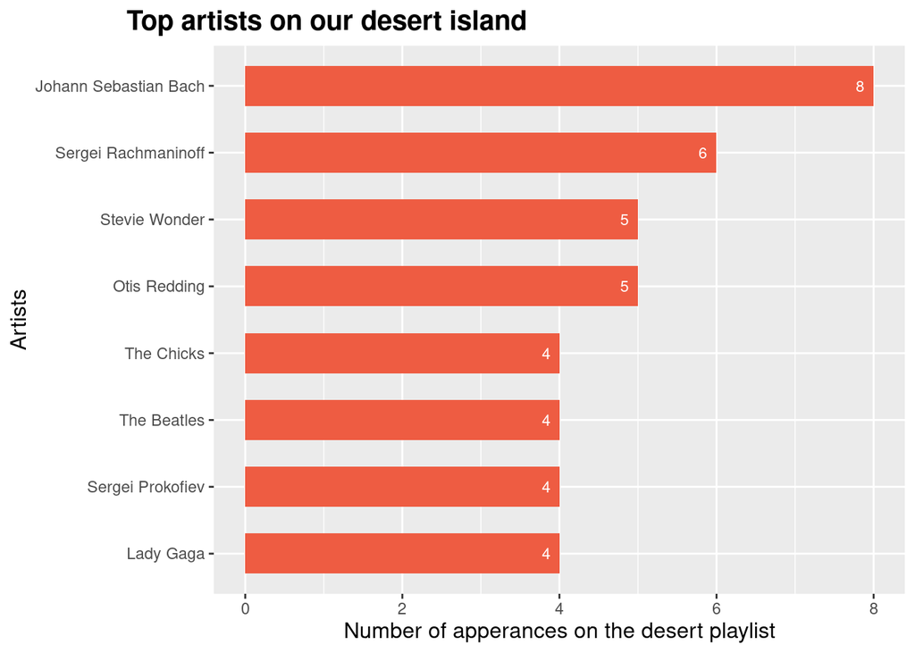

Although some of this is related to people submitting multiple, of the 132 songs, there is a wide variety of artists in the most frequent songs. Classics, jazz, and pop all populate our most selected pieces. The recording times also vary widly, ranging from 1961 to june of this year, although as a whole the median is decently close to present.

```
##         Min.      1st Qu.       Median         Mean      3rd Qu.         Max.
## "1961-01-01" "1984-12-30" "2006-01-01" "1999-12-01" "2017-01-27" "2021-06-16"
##         NA's
##         "18"
```

Through the use of spotify’s descriptors, we are able to look at how they interact together. Using a correlation plot on our desert island dataset, it appears very few things are closely related.

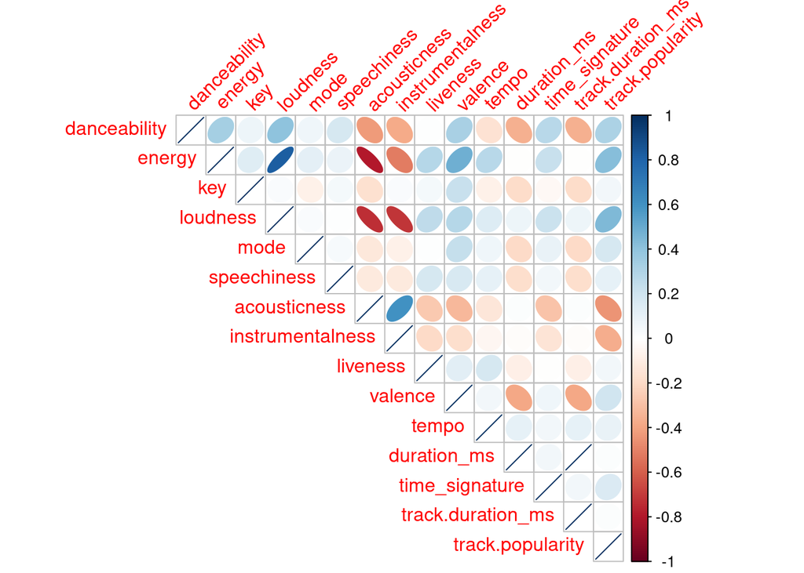

Energy and loudness is strongly correlated. Acousticness and instrumentalness are strongly negatively correlated with energy and loudness. This seems reasonable as there is very infrequently really loud instrumental or acappella songs.

| track.name | acousticness |
| --- | --- |
| Préludes - Book 2, L.123: 2. Feuilles mortes | 0.995 |
| Goldberg Variations, BWV 988: Aria | 0.995 |
| Goldberg Variations, BWV 988: Variation 5 a 1 ovvero 2 Clav. | 0.991 |
| 13 Préludes, Op. 32: VIII. Vivo in A Minor | 0.991 |

Particularly pulled out in this “acousticness” are piano pieces. At the top is Debussy in a rather slow and tender Prelude.

Interestingly, popularity (to all spotify listeners) is not very correlated with anything except loudness, and negatively to acousticness. It appears we like large, grand sounds. In fact, the majority of our playlist skews towards loudness.

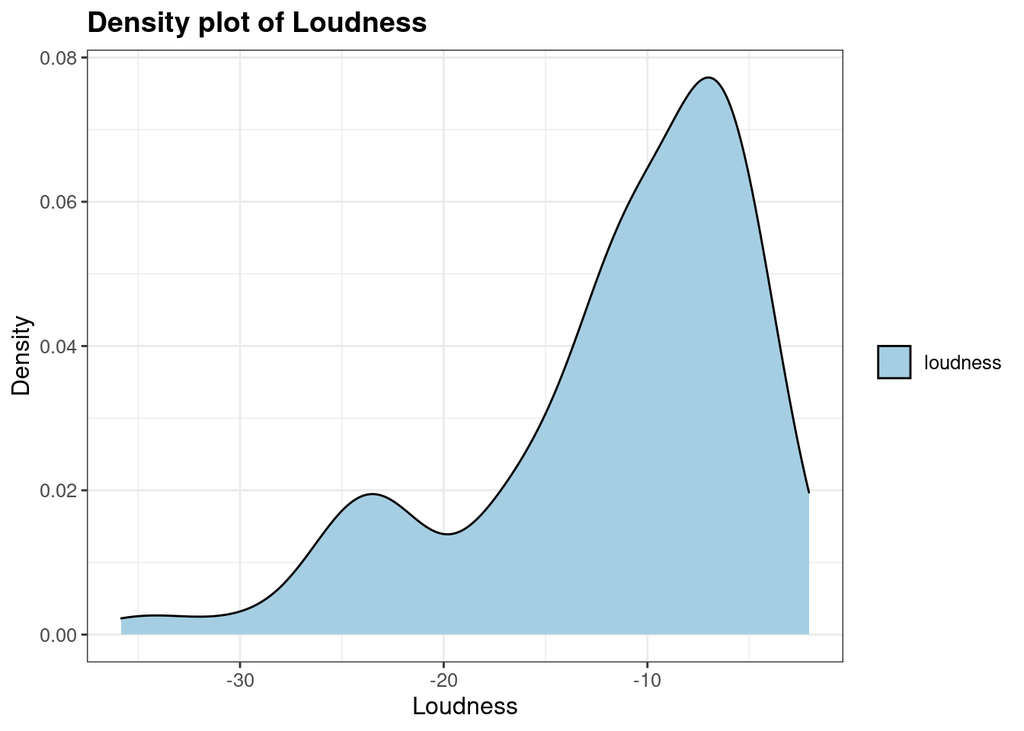

However, popularity and loudness are innevitably skewed towards more modern songs that have a larger listening audience. This is indeed true even for our playlist, as the top four songs for popularity have come out in the last four years.

| track.name | track.popularity | artists | track.album.release_date |
| --- | --- | --- | --- |
| bad guy | 85 | Billie Eilish | 2019-03-29 |
| Shallow | 83 | Lady Gaga | 2018-10-05 |
| Don’t Start Now | 82 | Dua Lipa | 2020-03-27 |
| everything i wanted | 82 | Billie Eilish | 2019-11-13 |

Although I am not able to personally derive meaning from the distribution of keys, I found it interest gradual choice and wide variety of keys.

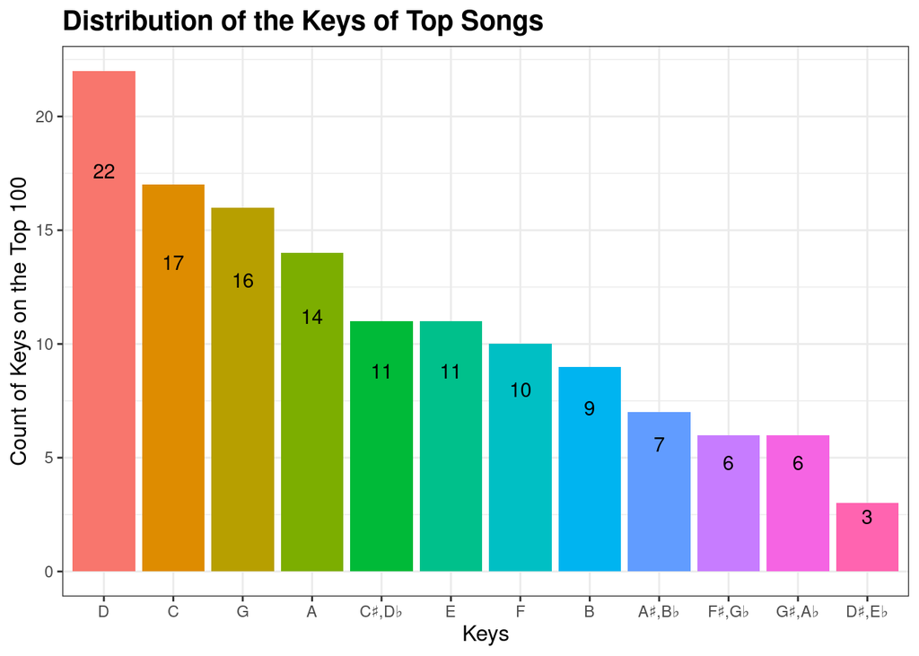

Over our desert island playlist, there is a suprising amount of normality to be seen within our 132 samples. Danceability, energy and valence all form rather normal curves and it appears that there is a good zone for making a piece that Columbia students like. That, or maybe we can even extrapolate that we are relatively normal (and don’t all listen to hard metal or something at the extreme).

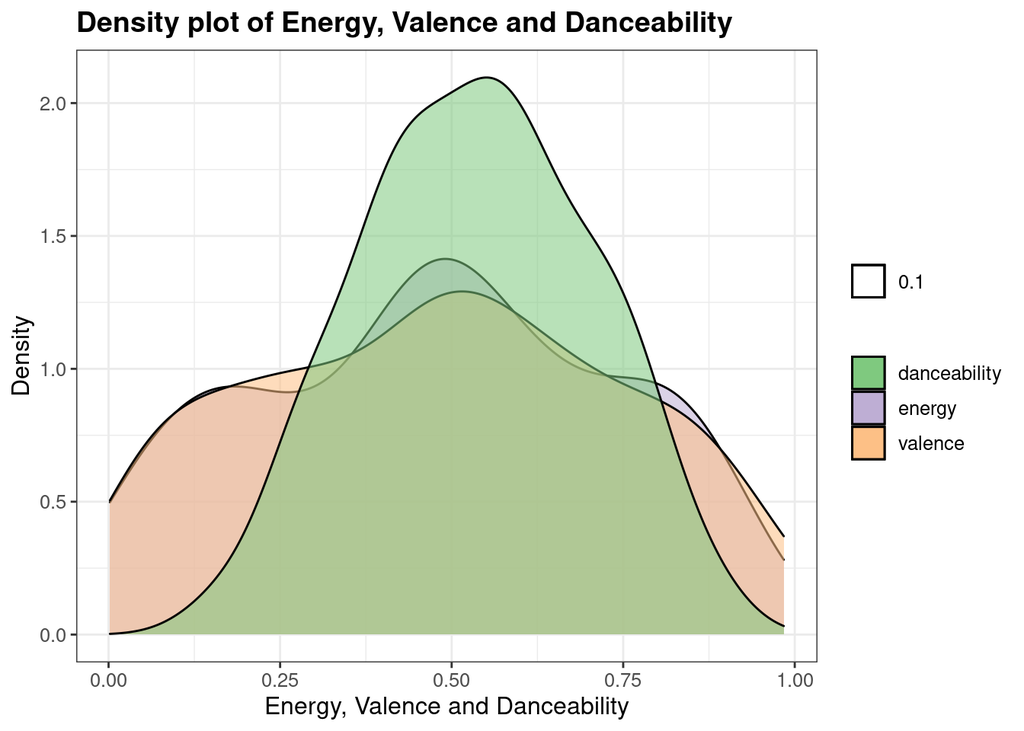

## What makes a masterpiece

While it appears there is little that unites the students of Columbia in their music choice, that isn’t necessarily surprising. As we have explored, there are a variety of reasons for music choices and there is certainly not one correct choice. However, this seems different from the “masterpieces” of the western canon. If there truly is a canon, then it would seem reasonable that there are some consistent common threads.

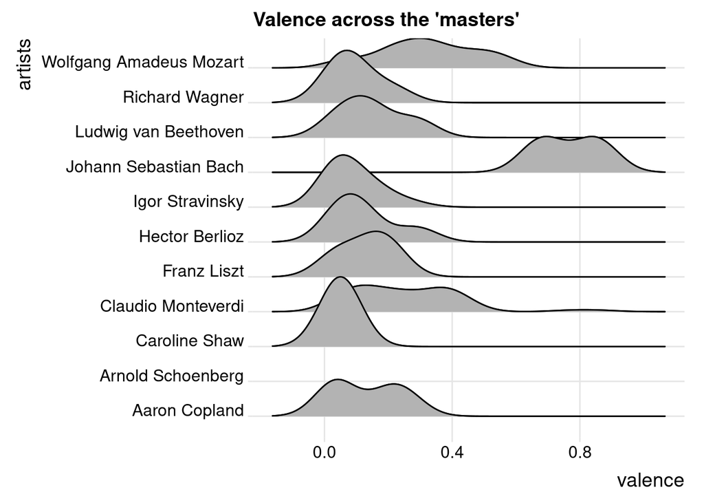

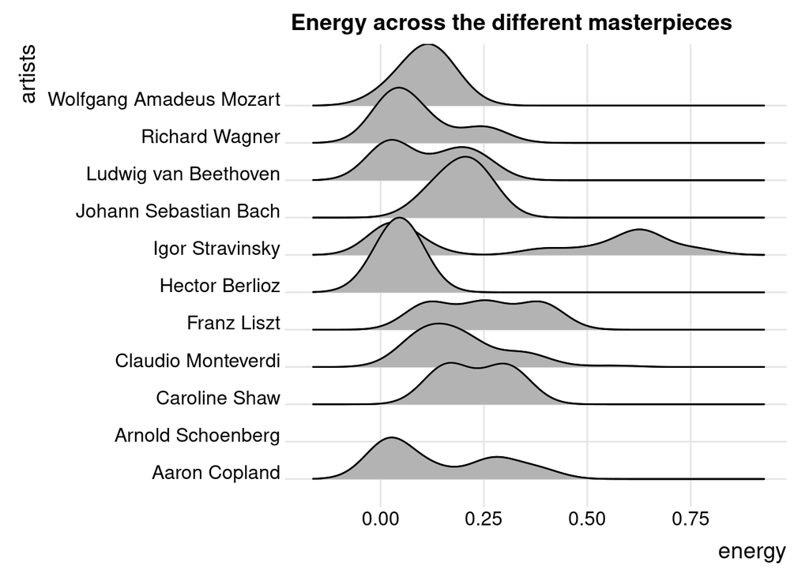

In this case, the statistics do a better job of showing Stravinsky as an outlier with a lot more comparitive energy. However, it is still interesting that the remaining works all score relatively low on energy.

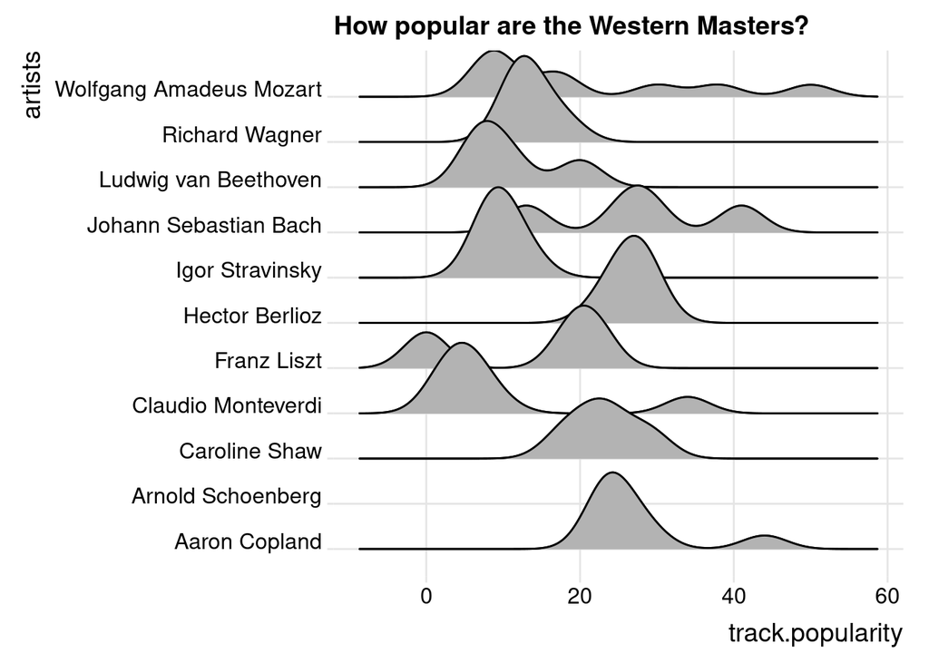

A rather ironic similarity between the “master’s” that we have studied is that at least for Spotify, they are not that popular. This is a little deceptive as there are a variety of recordings for each piece, so this dilutes popularity but none-the-less, they are less popular than many in our desert-island playlist.

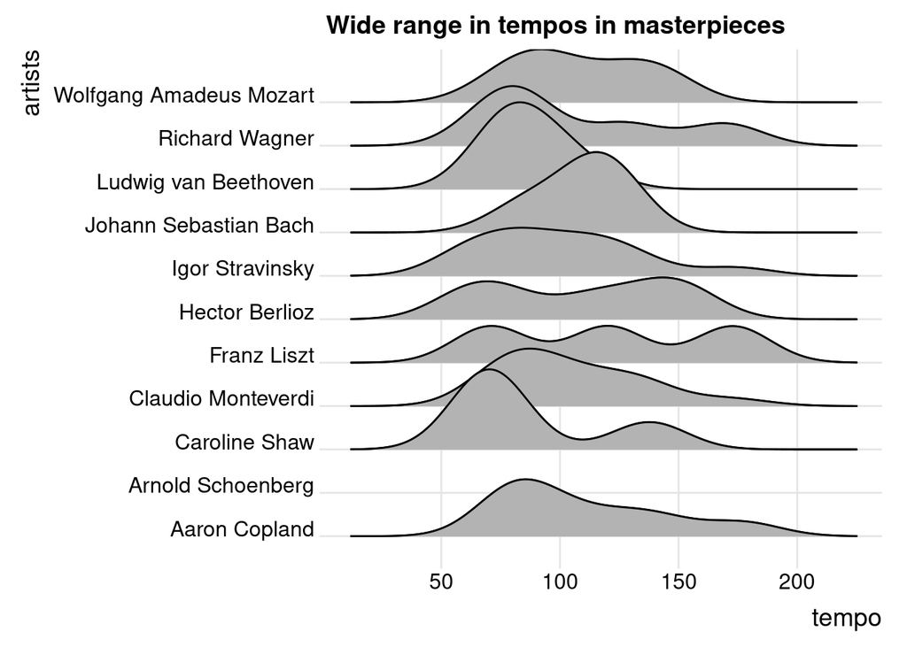

Also, it is good to know that almost any tempo is sufficient for writing a masterpiece. In fact, not only any tempo, but this shows that it requires a wide range of tempos. Maybe the one unique feature would be that these master composers are just that, a master at a much larger variety of musical techniques and the combination of those is what makes their pieces flourish. Of course, the Spotify API is not yet equiped to determine that.

```
##
## Call:
## lm(formula = tempo ~ danceability + energy + loudness + speechiness +
##     acousticness + instrumentalness + liveness + valence, data = spotify_data_masterpieces)
##
## Residuals:
##     Min      1Q  Median      3Q     Max
## -55.266 -19.373  -6.688   8.325  77.564
##
## Coefficients:
##                  Estimate Std. Error t value Pr(>|t|)
## (Intercept)      107.9023    29.9088   3.608 0.000453 ***
## danceability      38.5757    28.5932   1.349 0.179860
## energy            -6.1044    25.3999  -0.240 0.810488
## loudness          -0.1162     0.7012  -0.166 0.868626
## speechiness      -53.8089    57.1806  -0.941 0.348593
## acousticness     -30.6470    19.7769  -1.550 0.123885
## instrumentalness  13.6363     6.5872   2.070 0.040605 *
## liveness          30.9997    15.8662   1.954 0.053068 .
## valence            9.5471    16.8247   0.567 0.571480
## ---
## Signif. codes:  0 '***' 0.001 '**' 0.01 '*' 0.05 '.' 0.1 ' ' 1
##
## Residual standard error: 28.03 on 119 degrees of freedom
## Multiple R-squared:  0.1567, Adjusted R-squared:  0.09999
## F-statistic: 2.764 on 8 and 119 DF,  p-value: 0.007758
```

## Conclusion

In summary, there are not particularly defining features of what makes a masterpiece at least as presented through the Spotify API. Classical music and much of what we studied is slightly skewed in terms of modern analytics that look at loudness for example, but it doesn’t have a very clear set of prerequisite features. This seems to fit in with our class’s final discussion. Part of the greatness of the individual composers were there unique sense of expression and how they pushed the limitations of forms and styles available to them. It also shows that there is certainly more than one physical way to express yourself.

As for our desert island playlist, it shows what we already know - Columbia students are diverse in their backgrounds and this extends to our music choices. There is no set defining characteristic that can easily identify a song that will be loved by our undergraduate. Overall, what makes a masterpiece impactful and emotive may very well be individual.

### Coding References

My code and project file can be found in completeness here: https://github.com/noahlove/music-hum-data

Spotify API: https://developer.spotify.com/documentation/web-api/

Spotify R Package: https://github.com/charlie86/spotifyr

Kaggle Project Example with graphs repurposed: https://www.kaggle.com/cihanoklap/top-songs-on-spotify-what-makes-them-popular